# Predicting Weight Lifting Method

Robert Granger

December 21, 2015

## Introduction

Using pml data, let’s see if we can construct an algorithm that will allow us to correctly predict the manner in which a person conducted an exercise. After loading and cleaning the pml-dataset, we’ll look at a few exploratory graphs to see if any obvious predictors can be realized. Next we will look at two different models: RPART and Random Forest. We will select a model and then test for accuracy.

## Loading and Cleaning the Data

To begin, let’s load in the pml dataset. We have a dataset in which to conduct our analysis and a test dataset to evaluate upon when all finished.

```r
pmldata <- read.csv("pml-training.csv")
pmltestdata <- read.csv("pml-testing.csv")
```

This dataset is quite messy with many missing values. To begin let’s remove the columns where most of the data is missing:

```r
pmldata <- pmldata[,!is.na(pmltestdata[1,])]
pmltestdata <- pmltestdata[,!is.na(pmltestdata[1,])] #removes missing columns
```

Next let’s remove a couple more columns that won’t be useful in our predictions.

```r
pmldata <- pmldata[,-c(1,3,4,5)]
pmltestdata <- pmltestdata[,-c(1,3,4,5)] #removes unneccessary columns
```

## Load Relevant Libraries

This section just shows the libraries that will be used in our analysis.

```r
library(caret)
library(rattle)
library(ggplot2)
```

## Create Training and Testing Set

Here we’ll just split the dataset into a training set and a testing set.

```r
set.seed(61788)
inTrain <- createDataPartition(y=pmldata$classe,p=0.7,list=FALSE)
training <- pmldata[inTrain,]
testing <- pmldata[-inTrain,]
```

## Exploratory Analysis

Before selecting a model, let’s take a look at the data. Since we have so many predictor variables, I will just look at a subset of the data.

```r
summary(training[,c(1,2,3,7,20,33,46,56)])
```

```
##     user_name    new_window    num_window    total_accel_belt
##  adelmo  :2675   no :13452   Min.   :  1.0   Min.   : 0.00
##  carlitos:2186   yes:  285   1st Qu.:221.0   1st Qu.: 3.00
##  charles :2473               Median :423.0   Median :17.00
##  eurico  :2146               Mean   :430.4   Mean   :11.26
##  jeremy  :2425               3rd Qu.:645.0   3rd Qu.:18.00
##  pedro   :1832               Max.   :864.0   Max.   :29.00
##  total_accel_arm total_accel_dumbbell total_accel_forearm classe
##  Min.   : 1.00   Min.   : 0.00        Min.   :  0.00      A:3906
##  1st Qu.:17.00   1st Qu.: 4.00        1st Qu.: 29.00      B:2658
##  Median :27.00   Median :10.00        Median : 36.00      C:2396
##  Mean   :25.52   Mean   :13.76        Mean   : 34.75      D:2252
##  3rd Qu.:33.00   3rd Qu.:20.00        3rd Qu.: 41.00      E:2525
##  Max.   :65.00   Max.   :58.00        Max.   :108.00
```

Also let’s look at a feature plot of the total acceleration from the belt, arm, dumbell, and forearm.

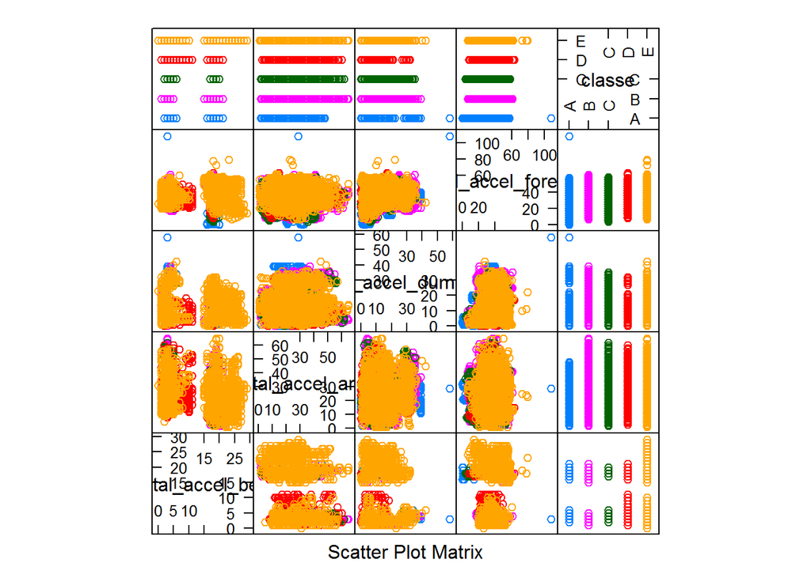

```r
featurePlot(x=training[,c(7,20,33,46,56)],
            y=training$classe,
            plot="pairs")
```

Quickly looking at these plots doesn’t seem to reveal any obvious predictors.

## Modeling

### Recursive Partitioning and Regression Trees (rpart)

For modelling the exercise type, we’ll be looking at two different techniques. The first is the Recursive Partitioning and Regression Trees (rpart).

```r
modFit1 <- train(classe~.,method="rpart",tuneLength=3,data=training)
```

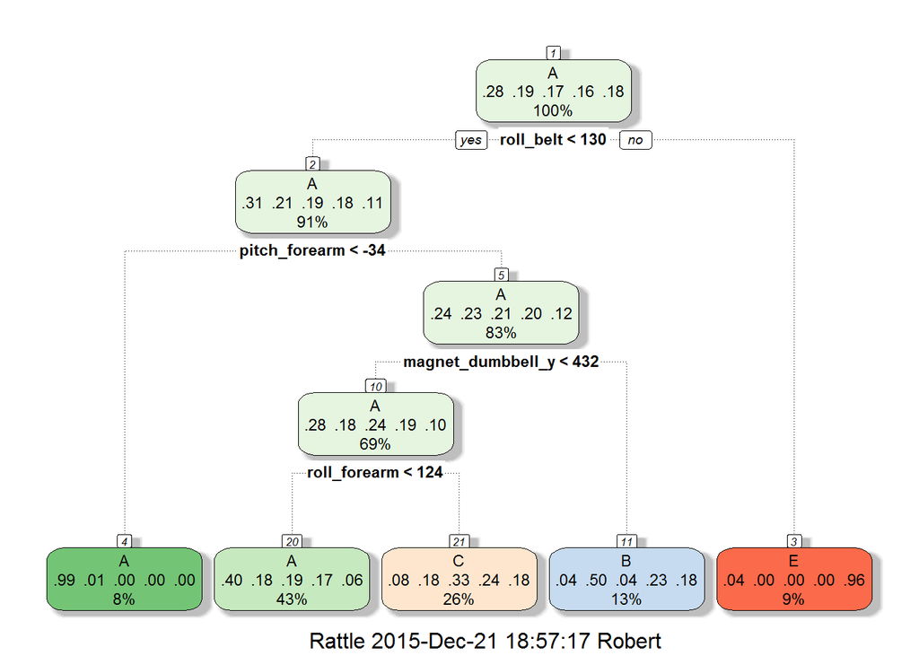

```r
fancyRpartPlot(modFit1$finalModel)
```

This extremely simple model is able to correctly identify 49.71 percent of the training data into the correct category.

Although we’ll be sacrificing simplicity, let’s increase the tunelength to 100 in order to improve accuracy.

```r
modFit2 <- train(classe~.,method="rpart",tuneLength=100,data=training)
```

We we’re able to correctly identify 97.52 percent of the data. Next, let’s look see how the algorithm compares on the testing set:

```r
confusionMatrix(predict(modFit2,testing),testing$classe)
```

```
## Confusion Matrix and Statistics
##
##           Reference
## Prediction    A    B    C    D    E
##          A 1649   26    1    7    7
##          B   10 1069   25   14    8
##          C   10   14  978   18    4
##          D    1   10   11  916   13
##          E    4   20   11    9 1050
##
## Overall Statistics
##
##                Accuracy : 0.9621
##                  95% CI : (0.9569, 0.9668)
##     No Information Rate : 0.2845
##     P-Value [Acc > NIR] : < 2.2e-16
##
##                   Kappa : 0.9521
##  Mcnemar's Test P-Value : 0.0001587
##
## Statistics by Class:
##
##                      Class: A Class: B Class: C Class: D Class: E
## Sensitivity            0.9851   0.9385   0.9532   0.9502   0.9704
## Specificity            0.9903   0.9880   0.9905   0.9929   0.9908
## Pos Pred Value         0.9757   0.9494   0.9551   0.9632   0.9598
## Neg Pred Value         0.9940   0.9853   0.9901   0.9903   0.9933
## Prevalence             0.2845   0.1935   0.1743   0.1638   0.1839
## Detection Rate         0.2802   0.1816   0.1662   0.1556   0.1784
## Detection Prevalence   0.2872   0.1913   0.1740   0.1616   0.1859
## Balanced Accuracy      0.9877   0.9633   0.9719   0.9715   0.9806
```

We managed to get 96% accuracty on the testing set. Let’s see if we can do better by using the random forest method.

### Random Forest

In this section we will be applying the random forest algorithm. Unfortunately, this can take a very long time. In order to reduce this time (and in the process unfortunately decrease accuracy), we will place a control.

```r
control <- trainControl(method = "repeatedcv",number = 5)
modFit3 <- train(classe~.,method="rf",data=training,trControl=control)
```

```r
confusionMatrix(predict(modFit3,training),training$classe)
```

```
## Confusion Matrix and Statistics
##
##           Reference
## Prediction    A    B    C    D    E
##          A 3906    0    0    0    0
##          B    0 2658    0    0    0
##          C    0    0 2396    0    0
##          D    0    0    0 2252    0
##          E    0    0    0    0 2525
##
## Overall Statistics
##
##                Accuracy : 1
##                  95% CI : (0.9997, 1)
##     No Information Rate : 0.2843
##     P-Value [Acc > NIR] : < 2.2e-16
##
##                   Kappa : 1
##  Mcnemar's Test P-Value : NA
##
## Statistics by Class:
##
##                      Class: A Class: B Class: C Class: D Class: E
## Sensitivity            1.0000   1.0000   1.0000   1.0000   1.0000
## Specificity            1.0000   1.0000   1.0000   1.0000   1.0000
## Pos Pred Value         1.0000   1.0000   1.0000   1.0000   1.0000
## Neg Pred Value         1.0000   1.0000   1.0000   1.0000   1.0000
## Prevalence             0.2843   0.1935   0.1744   0.1639   0.1838
## Detection Rate         0.2843   0.1935   0.1744   0.1639   0.1838
## Detection Prevalence   0.2843   0.1935   0.1744   0.1639   0.1838
## Balanced Accuracy      1.0000   1.0000   1.0000   1.0000   1.0000
```

```r
confusionMatrix(predict(modFit3,testing),testing$classe)
```

```
## Confusion Matrix and Statistics
##
##           Reference
## Prediction    A    B    C    D    E
##          A 1674    2    0    0    0
##          B    0 1136    3    0    2
##          C    0    0 1023    2    0
##          D    0    1    0  962    1
##          E    0    0    0    0 1079
##
## Overall Statistics
##
##                Accuracy : 0.9981
##                  95% CI : (0.9967, 0.9991)
##     No Information Rate : 0.2845
##     P-Value [Acc > NIR] : < 2.2e-16
##
##                   Kappa : 0.9976
##  Mcnemar's Test P-Value : NA
##
## Statistics by Class:
##
##                      Class: A Class: B Class: C Class: D Class: E
## Sensitivity            1.0000   0.9974   0.9971   0.9979   0.9972
## Specificity            0.9995   0.9989   0.9996   0.9996   1.0000
## Pos Pred Value         0.9988   0.9956   0.9980   0.9979   1.0000
## Neg Pred Value         1.0000   0.9994   0.9994   0.9996   0.9994
## Prevalence             0.2845   0.1935   0.1743   0.1638   0.1839
## Detection Rate         0.2845   0.1930   0.1738   0.1635   0.1833
## Detection Prevalence   0.2848   0.1939   0.1742   0.1638   0.1833
## Balanced Accuracy      0.9998   0.9982   0.9983   0.9988   0.9986
```

Astonishingly, this model was able to predict over 99 percent of the testing data accurately, hence our out-of-sample error is very small.

### Conclusion

Immediately looking at the data doesn’t seem to produce any obvious patterns. We were able to find a pattern, however, by applying a RPART and Random Forest model. Both predicted the testing set well but the Random Forest was much better. In the end, we were able to accurately predict 99% of the testing data.